# Practical 6: Measures of Association

Analysing Data

This practical will help you practice preparing for, conducting, and reporting correlation and chi-squared analyses in R. Before you start this practical, you should make sure you review the relevant lecture, as this practical assumes you already know what these analyses are and how to interpret the output. You should also use this practical in combination with the tutorial on the same topic.

# Setting Up

For this practical, you will need this worksheet, RStudio, and a new Markdown document. At this point, you should have enough experience with Markdown to make your own document. Remember that you can easily switch between windows with the `Alt` + `↹ Tab` (Windows) and `⌘ Command` + `⇥ Tab` (Mac OS) shortcuts.

### Task 1

Open your analysing_data `R` project in RStudio and create a new Markdown file. Since we will be practicing reporting using inline code, we will need Markdown later on. For the tasks, get into the habit of creating new code chunks as you go.

### Task 2

Aside from loading `tidyverse`, we will also be using `Hmisc`, `cowplot`, and `kableExtra`. If you don’t have any of these packages installed, do that now using `install.packages("package_name")`. **Remember that installing packages is a one-off thing** so don’t put the command that does it in your Markdown. Simply type it into the console and press `↵ Enter`. The `library()` commands should always go in a separate code chunk at the beginning of your Markdown document, so that your code will run correctly.

### Data and Design

As usual, we will need some data to work with. Since we put so much work into cleaning it previously, let’s use the harm dataset that we have seen previously, from [an actual paper by Swiderska and Küster (2018)](https://journals.sagepub.com/doi/10.1177/0301006618809919). You can find the data from the study at https://raw.githubusercontent.com/mivalek/AnD/master/data/harm_data.csv. You will also need to copy and paste in the code that you wrote from Practical 3 to clean this dataset.

The main idea in this study is that people attribute mental states to someone else to a higher degree if they also perceive them to be able to experience pain. The study created harmed and unharmed versions of human and robot avatars and showed them to participants in an independent-measures design (i.e. each participant only saw one of the four possible avatars). The participants were then asked to rate the avatars on a variety of mental awareness measures, such as consciousness and agency.

**CONTENT WARNING - Facial injury**: The design of this study involved showing participants pictures of photorealistic avatars, either human or robot. These avatars also were either unharmed, or had a facial wound resembling a burn. The images will not be replicated in this practical, but the original paper does contain these images on pg 5 of the linked PDF. This practical will only refer to the experimental manipulation, “harm”, in general terms.

### Task 3

Read in the data and write or copy (from the Week 3 practical) any code to clean it.

**Hint**: Copy and paste in code that saves something or makes a change to the dataset, ie uses the assignment operator `<-`.

# Data Preparation

As usual, before beginning any analysis, we will want to take a look at our data to make sure it’s clean and correct before we proceed. Since we’re using a dataset that we’ve cleaned already, we should be pretty happy with this, but let’s have a look again at these variables. The main reason is that you can run tests all day, but if you don’t know what the variables you are working with actually mean, that doesn’t do you much good!

## Codebook

| Variable name | Type | Description |
| --- | --- | --- |
| ID | factor | Unique participant ID |
| Condition | factor | Experimental condition; combination of Humanness and Harm. 1 = Human_Harmed, 2 = Human_Unharmed, 3 = Robot_Harmed, 4 = Robot_Unharmed |
| Humanness | factor | Avatar type: 1 = Human, 2 = Robot |
| Harm | factor | Avatar state: 1 = Harmed, 2 = Unharmed |
| Gender | factor | Participant gender: 1 = Male, 2 = Female |
| Age | continuous | Participant age in years |
| Pain | continuous | Does avatar have capacity to feel pain? 1 = Strongly disagree, 7 = Strongly agree |
| Experience | continuous | Does avatar have experience? 1 = Strongly disagree, 7 = Strongly agree |
| Agency | continuous | Does avatar have agency? 1 = Strongly disagree, 7 = Strongly agree |
| Consciousness | continuous | Does avatar have consciousness? 1 = Strongly disagree, 7 = Strongly agree |
| Empathy | continuous | Level of empathy for avatar: Higher number means more empathy felt |
| Attractiveness | continuous | Attractiveness of avatar: Higher number means more attractive |

### Task 4

Use the codebook above to check each variable, and make sure you understand how each variable was measured and that your data is coded the same way

**NOTE**: A previous version of the codebook had reversed the labels for `Harm`. Check your code against the corrected codebook here and ensure your data is correctly coded in both the `Harm` and `Condition` variables. If you need to, edit the cleaning code above and read in/clean the dataset again.

# Correlation

The first of the two analyses we will practice today is bivariate correlation. At the end of our analysis, we want to be able to report the strength and direction of the relationship between any two variables using the correlation coefficient *r*, as well as the associated *p*-value.

## Graphing

Once again, we should graph our data before we jump into running our analysis. Looking at summaries of numbers is good, but there’s no substitute for a good graph to help you understand your data.

### Task 5

Use `select()` and `pivot_longer` along with `ggplot()` to make multiple histograms, one each for `Pain`, `Experience`, and `Agency`, as below.

**Hint**: See the tutorial for how to do this. If you’re not confident using `pivot_longer()`, you can also make these three histograms separately.

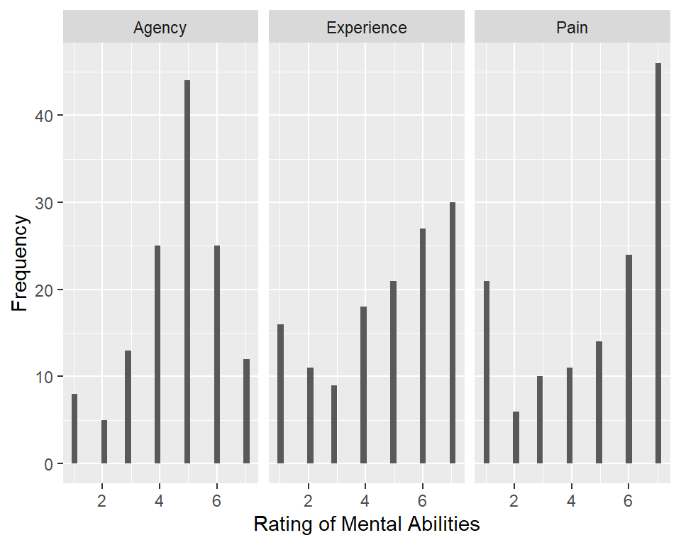

#### Task 5.1

Before you move on, stop and think about what the histograms are telling you about the distribution of each variable.

As we said above, we’re particularly interested in the relationship between `Pain` and `Experience`, and between `Pain` and `Agency`, in different conditions. Let’s have an overall look at the relationships between these variables with a correlation matrix.

## Correlation Matrix: The Big Picture

### Task 6

Create a correlation matrix of `Pain`, `Experience`, and `Agency` using `rcorr()` and save it as `harm.cor`.

**Hint**: Don’t forget that you have to change your data into a matrix before you can pipe it into `rcorr()`. [Have a look at the tutorial](http://users.sussex.ac.uk/~jm636/tut_05_cor_chisq.html#correlation) if you get stuck!

#### Task 6.1

Use `$` to get the matrix of correlation coefficients out of `harm.cor` and save it as `harm.cor.r`. Then, turn it into a nicely formatted table rounded to two decimal places, as below

Correlation Matrix

|  | Pain | Experience | Agency |
| --- | --- | --- | --- |
| Pain | 1.00 | 0.90 | 0.72 |
| Experience | 0.90 | 1.00 | 0.78 |
| Agency | 0.72 | 0.78 | 1.00 |

#### Task 6.2

Have a look at the correlations in the output. What is the strongest correlation? The weakest? Are they positive or negative? What does this mean? Write down your interpretation in your Markdown file.

### Task 7

Create a nicely formatted table of the *p*-values for the same correlation matrix, rounding to three decimal places, as below.

Correlation *p*-values

|  | Pain | Experience | Agency |
| --- | --- | --- | --- |
| Pain | NA | 0 | 0 |
| Experience | 0 | NA | 0 |
| Agency | 0 | 0 | NA |

#### Task 7.1

What do the values in this table mean? What do they tell you about the correlation coefficients from the previous table? Write down your interpretation in your Markdown file.

## Bivariate Correlations

We said above that we were particularly interested in the relationship between `Pain` and both `Experience` and `Agency`. Here we’re going to focus down even more and look at only `Pain` and `Experience`.

As a reminder, in the original study the researchers showed each participant one avatar, which could have been one of four possibilities. First, the avatar could have been either a human or robot avatar (`Humanness`). Second, the avatar could have been either harmed or unharmed (`Harm`). So, there were four possible conditions, each representing one of the four possible combinations of `Humanness` and `Harm` - namely, `Human_Unharmed`, `Human_Harmed`, `Robot_Unharmed`, and `Robot_Harmed` [variable `Condition`]. The study hypothesised that participants would rate the avatars more highly on `Experience` - that is, whether the avatar had feelings, desires, etc. - if they were harmed. They also thought that participants would rate the avatars more highly on experience if they thought the avatars were experiencing more pain (`Pain`).

### Task 8

Use `cor.test()` to calculate a correlation between `Pain` and `Experience` and save it as `pain_exp_corr`.

**Hint**: If you are having trouble using pipes, try `$` instead! See the tutorial for more details.

#### Task 8.1

Stop and look at the values that the output has given you. Based on what you have learned from the lecture, write down what you think this result means, and how you could interpret it.

#### Task 8.2

Create a scatterplot of these two variables to help you understand the correlation. Does this change your interpretation at all?

#### Task 8.3

Report the results of this correlation analysis and your interpretation in APA style, using inline reporting.

### Summary

If you’ve gotten this far and been able to successfully run and interpret the analyses and plots, then well done! You have a good grip on how to perform correlation analyses in R. However, we haven’t really answered the research question that we mentioned above: namely, does the relationship between Pain and Experience change depending on experimental condition? The next section will look into the data in more depth to understand this relationship, but this is **optional** if you would prefer to move on to chi-squared instead.

## Challenge Task: Interactions

### Task 9

This series of tasks will take a more in-depth look at the relationship between ratings of Pain and Experience in different experimental conditions.

What we are really looking at here is called an **interaction**. An interaction is when the relationship between two variables changes depending on a third variable. Here, for instance, the relationship between `Pain` and `Experience` may change depending on what condition participants were in (that is, whether they were giving those ratings for a human or robot avatar, and whether that avatar was harmed or unharmed). This is a complex topic that we will return to in second year, when we will learn how to evaluate interactions statistically. You **do not need to about interactions for this module** or for any assessments on this module. However, read on if you’re interested in investigating the patterns in the data and practicing your analysis and interpretation skills.

#### Task 9.1

Create a scatterplot of `Pain` vs `Experience`, with different coloured dots depending on `Harm`, and with separate panels for `Humanness`. What does this tell you about the relationship between `Pain` and `Experience` in different conditions?

**Hint**: Have a look at the Week 4 Practical, task 5.

Overall it seems that there were different patterns of responses in all four combinations of conditions. Let’s look into this further.

#### Task 9.2

Run correlation analyses for `Pain` vs `Experience` separately for each of the four levels of `Condition`. How do the correlation coefficients (i.e. values of *r*) differ in each of the four combinations of condtions? What does can you conclude from this?

**Hint**: Running these analyses will require some problem-solving, and there are a few different ways you could tackle this problem. If you get stuck, try looking at the `formula` options in the help documentation for `cor.test()`.

# Chi-Squared

Our second test of association is the chi-squared test. Unlike *r*, we will use chi-squared on frequency data to find out whether two categorical variables are independent of each other or not.

## Data Preparation

We have the same problem here that we had in the tutorial. Specifically, we need to perform a chi-squared test on categorical data. Here we have five categorical variables, but it’s pointless to perform a chi-squared analysis on any of them. So, we’ll need to create a categorical variable, as we did in the tutorial, before we can practice with the chi-squared analysis.

### Task 10

Why is it that there’s no point in analysing our existing categorical variables with chi-squared? Look at the variables we have and think about what the analysis would tell us.

Harm Dataset Codebook

| Variable name | Type | Description |
| --- | --- | --- |
| ID | factor | Unique participant ID |
| Condition | factor | Experimental condition; combination of Humanness and Harm. 1 = Human_Harmed, 2 = Human_Unharmed, 3 = Robot_Harmed, 4 = Robot_Unharmed |
| Humanness | factor | Avatar type: 1 = Human, 2 = Robot |
| Harm | factor | Avatar state: 1 = Harmed, 2 = Unharmed |
| Gender | factor | Participant gender: 1 = Male, 2 = Female |
| Age | continuous | Participant age in years |
| Pain | continuous | Does avatar have capacity to feel pain? 1 = Strongly disagree, 7 = Strongly agree |
| Experience | continuous | Does avatar have experience? 1 = Strongly disagree, 7 = Strongly agree |
| Agency | continuous | Does avatar have agency? 1 = Strongly disagree, 7 = Strongly agree |
| Consciousness | continuous | Does avatar have consciousness? 1 = Strongly disagree, 7 = Strongly agree |
| Empathy | continuous | Level of empathy for avatar: Higher number means more empathy felt |
| Attractiveness | continuous | Attractiveness of avatar: Higher number means more attractive |

The issue is that all of the outcome variables in our dataset - `Pain`, `Experience`, `Agency`, and `Consciousness`, `Empathy`, and `Attractiveness` - are all continuous rather than categorical variables. However, we saw in the tutorial that we can create a categorical variable out of a continous variable. We’ll do this again here using a **median split**, which simply means that we find the middle value in a variable and split the variable in half. Values below the median go in one category (e.g. “low”), and values above the median go in another (e.g. “high”). Since we haven’t looked at it much, we’ll do this with `Consciousness`.

### Task 11

Run the following code to create a new factor variable, `Conc_med`, out of the `Consciousness` variable, and ask for a summary to have a look at it. The general format of the code should look familiar to you.

See the “What For?” box in the tutorial for more on `ifelse()` if you’re interested in how this code works. Don’t worry if you don’t understand it completely; you just need to understand that the new variable contains a new factor called `Conc_med`, which captures whether participants gave low or high ratings for avatar consciousness.

```r
data <- data %>%
  mutate(Conc_med = ifelse(Consciousness < median(Consciousness), "Low", "High"),
         Conc_med = factor(Conc_med))
```

### Median Splits

Changing the way a variable is measured, as we have done with `Consciousness`, above, is not an uncommon practice, but it should be done carefully and thoughtfully. In some cases, splitting at the median (as we have done) is the most sensible option; in other cases, you may want to split at the mean, or at the quartiles. Which you do depends on understanding very clearly what question you asked your participants and what your data means before you do it.

Although the median split is a simple mathematical operation, you should consider carefully whether this is a good idea, including the following points:

1. When you change data from continuous to categorical in this way, you lose detail. For example, in this case, because the median was 4.5, everyone who gave a rating below this was categorised as giving as “low” rating for the consciousness of the avatar. So if Participant gave a 4 but Participant B gave a 1, this distinction was lost.
2. People who gave more similar ratings could be in different categories. For example, if Participant A rated consciousness as a 4, they were put in the same category as Participant B who rated 1, but a **different** category from Participant C, who rated 5. So, Participants A (low) and C (high) actually rated consciousness more similarly than A and B did.
3. Is it really a good idea to analyse data that your participants haven’t actually given you? That is, you can’t be sure whether, if you had actually asked your participants, “Would you say that this avatar has a high or low level of consciousness?” they would respond the same way as your median split has categorised them.

Altogether, it’s generally best practice to analyse the data you actually collected. However, you will see median splits reported in papers, and it’s useful for us here to practice chi-squared specifically, so we’ll make use of it, cautiously.

Before we move on, we should get some summaries of our data to help us get an idea of what’s going on.

### Task 12

Create contingency (frequency) tables of `Conc_med`, split up by `Humanness`, and split up by `Harm`. Save them into new objects, e.g. `conc_human_tab` and `conc_harm_tab`. Then, create nicely formatted versions of each using `kable`.

Consciousness by Avatar Humanness

|  | Human | Robot |
| --- | --- | --- |
| High | 48 | 18 |
| Low | 17 | 49 |

Consciousness by Avatar Harm

|  | Harmed | Unharmed |
| --- | --- | --- |
| High | 37 | 29 |
| Low | 24 | 42 |

## Graphing

As in the tutorial, it’s a good idea to visualise your data besides just looking at the numbers. (It’s also good practice for your lab report!).

### Task 13

Create two bar graphs representing the counts in the two tables above (ie `Conc_med` vs `Humanness` and `Conc_med` vs `Harm`).

**Hints:**

- In `aes()`, use `fill = variable_name` to split up the bars on the x-axis by that variable
- In your geom function, use `position = "dodge"` to put the bars side by side
  - You can also try leaving this out to see what happens!
- Use `labs()` to rename the labels informatively.
- Use `scale_fill_manual(name = "...", values = c(...))` to change the legend title and the colours of the bars.
- Use a nice theme (hint: cows are very stylish!)

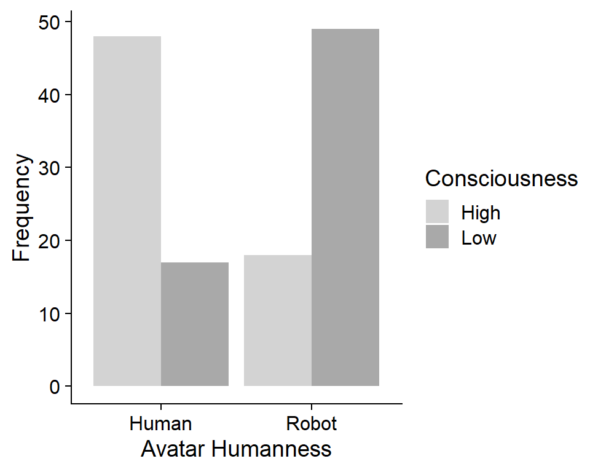

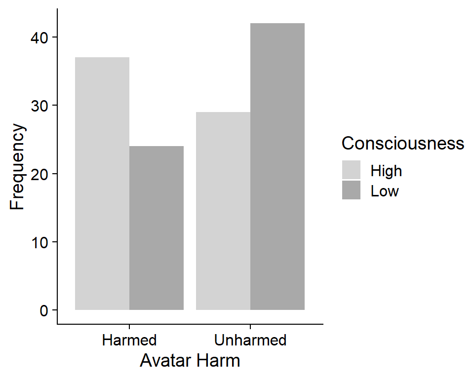

## Analysis with `chisq.test()`

Now that we know what the general pattern of the data looks like, we can run our statistical analysis to find out whether the counts in different categories are different enough to believe that there may be an association between them.

### Task 14

Use the contingency tables you created above to run two chi-squared tests and save the output for each in a new object.

#### Task 14.1

Use subsetting to get a table of expected frequencies and format it nicely for both analyses. Have we met the assumptions for the chi-squared test?

Expected Frequencies

|  | Harmed | Unharmed |
| --- | --- | --- |
| High | 30.5 | 35.5 |
| Low | 30.5 | 35.5 |

Expected Frequencies

|  | Human | Robot |
| --- | --- | --- |
| High | 32.5 | 33.5 |
| Low | 32.5 | 33.5 |

To complete our analysis, we need to report our results properly. This not only means writing down our interpretation, but also formally reporting the results of our analysis. As we’ve said before, it’s very useful to do this using inline code.

#### Task 14.2

Report the results of both chi-squared analyses using inline code. Refer to the tutorial for examples of phrasing and inline code, but try writing the text yourself.

**Hint**: You can use `str()` to remind yourself of what’s stored in the output.

# Summary

Well done! You are making excellent progress with your analysis skills in R. You can use this practical and the accompanying tutorial as a template for the analysis you should do and report in your lab report, if you are writing about the green study. If you are writing about the red study, you should instead use next week’s tutorial and practical, covering *t*-tests

In sum, we’ve practiced the following tasks:

- How to prepare and visualise data for correlation and chi-squared analyses
- How to run these analyses, read the output, and store them as `htest` objects
- How to use the subsetting operator `$` to easily report results
- How to interpret the statistical results of these tests in real-world terms

**Good job!**

That’s all for today. See you soon!